# ZooniverseProcessing

Taiki Sakai

2022-12-14

We only want to look at data from most recent workflows 8.15 and 17.2

Check number of labels selected for each annoation

```
## nLabels
##    0    1    2    3    4
##    1 2546   47    3    1
```

“Multiple selections OK” was included by default, so we want to re-work these multi-label cases.

```
##
##                             8.15 17.2
##   Humpback whales             78  285
##   Humpback whales and ships  178  503
##   None of the above          191  519
##   Ship noise                 319  510
```

We want to look at only the retired images, images that are not yet retired will have `NULL` for the retired portion of that JSON

```
##
## FALSE  TRUE
##   740  1858
```

Now we want to look at the distribution of labels for each image.

The `maxLabs` dataframe has one row for every image. Each row shows the proportion of votes for each label, the number of votes, the max proportion value, and the label for the max value. In case of ties for max proportion these are listed as “N tied”.

```
## tibble [153 × 9] (S3: tbl_df/tbl/data.frame)
##  $ subject                  : chr [1:153] "82173425" "82173448" "82173451" "82173453" ...
##  $ Humpback whales          : num [1:153] 0.273 0 0.2 0.1 0.4 ...
##  $ Humpback whales and ships: num [1:153] 0.0909 0.1 0 0 0.1 ...
##  $ None of the above        : num [1:153] 0.636 0.2 0.6 0.6 0.5 ...
##  $ Ship noise               : num [1:153] 0 0.7 0.2 0.3 0 ...
##  $ n                        : int [1:153] 11 10 10 10 10 10 11 9 10 11 ...
##  $ max                      : Named num [1:153] 0.636 0.7 0.6 0.6 0.5 ...
##   ..- attr(*, "names")= chr [1:153] "None of the above" "Ship noise" "None of the above" "None of the above" ...
##  $ maxLabel                 : chr [1:153] "None of the above" "Ship noise" "None of the above" "None of the above" ...
##  $ image                    : chr [1:153] "Deci44100_CCES_010_1033" "Deci44100_CCES_010_1074" "Deci44100_CCES_010_1127" "Deci44100_CCES_010_1165" ...
```

Plotting distribution of most-confident class for each image. Ideally these would all be 1 if all reviewers agreed on the label

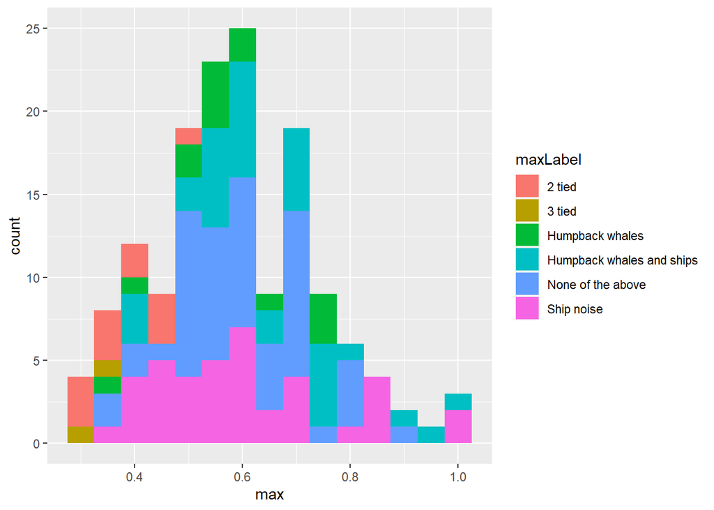

Compare labels for each image with expert label.

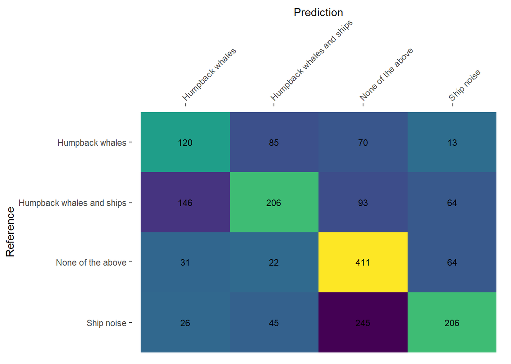